# Supervised Learning - Foundations: ReCell

*Marks: 60*

## Context

Buying and selling used phones and tablets used to be something that happened on a handful of online marketplace sites. But the used and refurbished device market has grown considerably over the past decade, and a new IDC (International Data Corporation) forecast predicts that the used phone market would be worth \$52.7bn by 2023 with a compound annual growth rate (CAGR) of 13.6% from 2018 to 2023. This growth can be attributed to an uptick in demand for used phones and tablets that offer considerable savings compared with new models.

Refurbished and used devices continue to provide cost-effective alternatives to both consumers and businesses that are looking to save money when purchasing one. There are plenty of other benefits associated with the used device market. Used and refurbished devices can be sold with warranties and can also be insured with proof of purchase. Third-party vendors/platforms, such as Verizon, Amazon, etc., provide attractive offers to customers for refurbished devices. Maximizing the longevity of devices through second-hand trade also reduces their environmental impact and helps in recycling and reducing waste. The impact of the COVID-19 outbreak may further boost this segment as consumers cut back on discretionary spending and buy phones and tablets only for immediate needs.

## Objective

The rising potential of this comparatively under-the-radar market fuels the need for an ML-based solution to develop a dynamic pricing strategy for used and refurbished devices. ReCell, a startup aiming to tap the potential in this market, has hired you as a data scientist. They want you to analyze the data provided and build a linear regression model to predict the price of a used phone/tablet and identify factors that significantly influence it.

## Data Description

The data contains the different attributes of used/refurbished phones and tablets. The detailed data dictionary is given below.

**Data Dictionary**

- brand_name: Name of manufacturing brand
- os: OS on which the device runs
- screen_size: Size of the screen in cm
- 4g: Whether 4G is available or not
- 5g: Whether 5G is available or not
- main_camera_mp: Resolution of the rear camera in megapixels
- selfie_camera_mp: Resolution of the front camera in megapixels
- int_memory: Amount of internal memory (ROM) in GB
- ram: Amount of RAM in GB
- battery: Energy capacity of the device battery in mAh
- weight: Weight of the device in grams
- release_year: Year when the device model was released
- days_used: Number of days the used/refurbished device has been used
- new_price: Price of a new device of the same model in euros
- used_price: Price of the used/refurbished device in euros

## Importing necessary libraries and data

```python
# this will help in making the Python code more structured automatically (good coding practice)
%load_ext nb_black

# Libraries to help with reading and manipulating data
import numpy as np
import pandas as pd

# Libraries to help with data visualization
import matplotlib.pyplot as plt
import seaborn as sns

sns.set()

# For randomized data splitting
from sklearn.model_selection import train_test_split

# To build linear regression_model
import statsmodels.api as sm

# To check model performance
from sklearn.metrics import mean_absolute_error, mean_squared_error

# Removes the limit for the number of displayed columns
pd.set_option("display.max_columns", None)
# Sets the limit for the number of displayed rows
pd.set_option("display.max_rows", 200)
```

## Data Overview

- Observations
- Sanity checks

```python
# loading the dataset
df = pd.read_csv("used_device_data.csv", engine="python")
```

```python
# checking the shape of the data
print(f"There are {df.shape[0]} rows and {df.shape[1]} columns.")  # f-string
```

```
There are 3454 rows and 15 columns.
```

```python
# sample of the data
df.sample(n=10, random_state=1)
```

|  | brand_name | os | screen_size | 4g | 5g | main_camera_mp | selfie_camera_mp | int_memory | ram | battery | weight | release_year | days_used | new_price | used_price |
| --- | --- | --- | --- | --- | --- | --- | --- | --- | --- | --- | --- | --- | --- | --- | --- |
| 866 | Others | Android | 15.24 | no | no | 8.00 | 2.0 | 16.0 | 4.00 | 3000.0 | 206.0 | 2014 | 632 | 179.61 | 56.76 |
| 957 | Celkon | Android | 10.16 | no | no | 3.15 | 0.3 | 512.0 | 0.25 | 1400.0 | 140.0 | 2013 | 637 | 48.65 | 16.45 |
| 280 | Infinix | Android | 15.39 | yes | no | NaN | 8.0 | 32.0 | 2.00 | 5000.0 | 185.0 | 2020 | 329 | 88.88 | 79.10 |
| 2150 | Oppo | Android | 12.83 | yes | no | 13.00 | 16.0 | 64.0 | 4.00 | 3200.0 | 148.0 | 2017 | 648 | 281.30 | 107.54 |
| 93 | LG | Android | 15.29 | yes | no | 13.00 | 5.0 | 32.0 | 3.00 | 3500.0 | 179.0 | 2019 | 216 | 200.42 | 91.62 |
| 1040 | Gionee | Android | 12.83 | yes | no | 13.00 | 8.0 | 32.0 | 4.00 | 3150.0 | 166.0 | 2016 | 970 | 279.87 | 104.13 |
| 3170 | ZTE | Others | 10.16 | no | no | 3.15 | 5.0 | 16.0 | 4.00 | 1400.0 | 125.0 | 2014 | 1007 | 69.71 | 43.14 |
| 2742 | Sony | Android | 12.70 | yes | no | 20.70 | 2.0 | 16.0 | 4.00 | 3000.0 | 170.0 | 2013 | 1060 | 330.24 | 83.33 |
| 102 | Meizu | Android | 15.29 | yes | no | NaN | 20.0 | 128.0 | 6.00 | 3600.0 | 165.0 | 2019 | 332 | 420.17 | 142.51 |
| 1195 | HTC | Android | 10.29 | no | no | 8.00 | 2.0 | 32.0 | 4.00 | 2000.0 | 146.0 | 2015 | 892 | 131.50 | 68.57 |

```python
# checking column datatypes and number of non-null values
df.info()
```

```
<class 'pandas.core.frame.DataFrame'>
RangeIndex: 3454 entries, 0 to 3453
Data columns (total 15 columns):
 #   Column            Non-Null Count  Dtype
---  ------            --------------  -----
 0   brand_name        3454 non-null   object
 1   os                3454 non-null   object
 2   screen_size       3454 non-null   float64
 3   4g                3454 non-null   object
 4   5g                3454 non-null   object
 5   main_camera_mp    3275 non-null   float64
 6   selfie_camera_mp  3452 non-null   float64
 7   int_memory        3450 non-null   float64
 8   ram               3450 non-null   float64
 9   battery           3448 non-null   float64
 10  weight            3447 non-null   float64
 11  release_year      3454 non-null   int64
 12  days_used         3454 non-null   int64
 13  new_price         3454 non-null   float64
 14  used_price        3454 non-null   float64
dtypes: float64(9), int64(2), object(4)
memory usage: 404.9+ KB
```

```python
# looking at which columns have the most missing values
df.isnull().sum().sort_values(ascending=False)
```

```
main_camera_mp      179
weight                7
battery               6
int_memory            4
ram                   4
selfie_camera_mp      2
brand_name            0
os                    0
screen_size           0
4g                    0
5g                    0
release_year          0
days_used             0
new_price             0
used_price            0
dtype: int64
```

#### #Observations:Main_camera_mp has the highest missing values Weight has 7 missing values

```python
# calculate the medians
df.median()
```

```
screen_size           12.830
main_camera_mp         8.000
selfie_camera_mp       5.000
int_memory            32.000
ram                    4.000
battery             3000.000
weight               160.000
release_year        2015.500
days_used            690.500
new_price            189.785
used_price            81.870
dtype: float64
```

```python
# counting the number of missing values per row
df.isnull().sum(axis=1).value_counts()
```

```
0    3253
1     200
2       1
dtype: int64
```

#### Observations:

There are 200 rows with one missing values and 1 row with 2 missing values

#### The Main_Camera_mp column has a lot of missing values.

```python
# fill missing values with their corresponding medians a fillna
df1=df[["main_camera_mp", "weight", "battery", "int_memory", "ram", "selfie_camera_mp"]] = (
    df[
        ["main_camera_mp", "weight", "battery", "int_memory", "ram", "selfie_camera_mp"]
    ].fillna(
        df[
            [
                "main_camera_mp",
                "weight",
                "battery",
                "int_memory",
                "ram",
                "selfie_camera_mp"
            ]
        ].median()))
df.sample(10)
```

|  | brand_name | os | screen_size | 4g | 5g | main_camera_mp | selfie_camera_mp | int_memory | ram | battery | weight | release_year | days_used | new_price | used_price |
| --- | --- | --- | --- | --- | --- | --- | --- | --- | --- | --- | --- | --- | --- | --- | --- |
| 2560 | Samsung | Android | 20.32 | no | no | 3.15 | 1.3 | 16.0 | 4.0 | 4450.0 | 320.0 | 2014 | 1002 | 268.96 | 112.32 |
| 98 | Meizu | Android | 15.37 | yes | no | 8.00 | 16.0 | 128.0 | 6.0 | 4500.0 | 183.0 | 2019 | 449 | 251.22 | 106.22 |
| 1504 | Lenovo | Android | 12.75 | yes | no | 13.00 | 8.0 | 32.0 | 4.0 | 4000.0 | 165.0 | 2017 | 763 | 170.67 | 82.57 |
| 1276 | Huawei | Android | 25.43 | yes | no | 5.00 | 2.0 | 32.0 | 4.0 | 5100.0 | 460.0 | 2018 | 651 | 199.93 | 101.76 |
| 2781 | Spice | Android | 25.40 | no | no | 3.15 | 0.3 | 16.0 | 4.0 | 7600.0 | 158.0 | 2013 | 917 | 179.34 | 80.78 |
| 1386 | Huawei | Android | 15.27 | yes | no | 13.00 | 5.0 | 16.0 | 4.0 | 4050.0 | 202.0 | 2014 | 722 | 331.40 | 129.37 |
| 579 | Others | Android | 15.24 | yes | no | 13.00 | 5.0 | 64.0 | 4.0 | 5020.0 | 209.8 | 2016 | 636 | 419.48 | 101.23 |
| 812 | Asus | Android | 17.78 | no | no | 1.00 | 1.2 | 32.0 | 4.0 | 4270.0 | 370.0 | 2013 | 753 | 109.48 | 64.25 |
| 2310 | Others | Android | 12.70 | no | no | 13.00 | 5.0 | 16.0 | 4.0 | 2500.0 | 154.0 | 2015 | 1007 | 160.75 | 75.79 |
| 2965 | Xiaomi | Android | 12.70 | yes | no | 13.00 | 5.0 | 32.0 | 4.0 | 4100.0 | 156.0 | 2016 | 734 | 160.66 | 87.91 |

```python
# Recheck the mising values: No missing values
df.isna().sum()
```

```
brand_name          0
os                  0
screen_size         0
4g                  0
5g                  0
main_camera_mp      0
selfie_camera_mp    0
int_memory          0
ram                 0
battery             0
weight              0
release_year        0
days_used           0
new_price           0
used_price          0
dtype: int64
```

```python
# Rechecking the median after missing values treatment
df.median()
```

```
screen_size           12.830
main_camera_mp         8.000
selfie_camera_mp       5.000
int_memory            32.000
ram                    4.000
battery             3000.000
weight               160.000
release_year        2015.500
days_used            690.500
new_price            189.785
used_price            81.870
dtype: float64
```

### Observations:

After using the fillna function the number of missing values have been filled with the medians of the columns. The median hasn't been affected

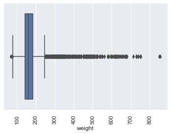

```python
## Outlier detection in the weight column
sns.boxplot(data=df, x="weight")
plt.xticks(rotation=90)

plt.show()
```

##### Observations:

Shows high number of outliers

```python
#I have decided to RENAME the 4g and 5g column to
# their string equivalents to make them easier to convert them to
# categorical data frames.As you will encounter an error if you try
# to convert them directly because of their numerical value.

df1 = df.rename(columns={"4g": "Four_G", "5g": "Five_G"}, inplace=True)
df.head()
```

|  | brand_name | os | screen_size | Four_G | Five_G | main_camera_mp | selfie_camera_mp | int_memory | ram | battery | weight | release_year | days_used | new_price | used_price |
| --- | --- | --- | --- | --- | --- | --- | --- | --- | --- | --- | --- | --- | --- | --- | --- |
| 0 | Honor | Android | 14.50 | yes | no | 13.0 | 5.0 | 64.0 | 3.0 | 3020.0 | 146.0 | 2020 | 127 | 111.62 | 74.26 |
| 1 | Honor | Android | 17.30 | yes | yes | 13.0 | 16.0 | 128.0 | 8.0 | 4300.0 | 213.0 | 2020 | 325 | 249.39 | 174.53 |
| 2 | Honor | Android | 16.69 | yes | yes | 13.0 | 8.0 | 128.0 | 8.0 | 4200.0 | 213.0 | 2020 | 162 | 359.47 | 165.85 |
| 3 | Honor | Android | 25.50 | yes | yes | 13.0 | 8.0 | 64.0 | 6.0 | 7250.0 | 480.0 | 2020 | 345 | 278.93 | 169.93 |
| 4 | Honor | Android | 15.32 | yes | no | 13.0 | 8.0 | 64.0 | 3.0 | 5000.0 | 185.0 | 2020 | 293 | 140.87 | 80.64 |

```python
# Convert object Data_types into Categorical
df["brand_name"] = df.brand_name.astype("category")
df["os"] = df.os.astype("category")
df["Four_G"] = df.Four_G.astype("category")
df["Five_G"] = df.Five_G.astype("category")
df.dtypes  # Checking Datatypes
```

```
brand_name          category
os                  category
screen_size          float64
Four_G              category
Five_G              category
main_camera_mp       float64
selfie_camera_mp     float64
int_memory           float64
ram                  float64
battery              float64
weight               float64
release_year           int64
days_used              int64
new_price            float64
used_price           float64
dtype: object
```

##### Observations:

All the Object Datatypes have been converted to categorical datatypes

```python
# Let's look at the statistical summary of the data
df.describe(include="all").T
```

|  | count | unique | top | freq | mean | std | min | 25% | 50% | 75% | max |
| --- | --- | --- | --- | --- | --- | --- | --- | --- | --- | --- | --- |
| brand_name | 3454 | 34 | Others | 502 | NaN | NaN | NaN | NaN | NaN | NaN | NaN |
| os | 3454 | 4 | Android | 3214 | NaN | NaN | NaN | NaN | NaN | NaN | NaN |
| screen_size | 3454.0 | NaN | NaN | NaN | 13.713115 | 3.80528 | 5.08 | 12.7 | 12.83 | 15.34 | 30.71 |
| Four_G | 3454 | 2 | yes | 2335 | NaN | NaN | NaN | NaN | NaN | NaN | NaN |
| Five_G | 3454 | 2 | no | 3302 | NaN | NaN | NaN | NaN | NaN | NaN | NaN |
| main_camera_mp | 3454.0 | NaN | NaN | NaN | 9.384534 | 4.700148 | 0.08 | 5.0 | 8.0 | 13.0 | 48.0 |
| selfie_camera_mp | 3454.0 | NaN | NaN | NaN | 6.553329 | 6.968453 | 0.0 | 2.0 | 5.0 | 8.0 | 32.0 |
| int_memory | 3454.0 | NaN | NaN | NaN | 54.546957 | 84.926611 | 0.01 | 16.0 | 32.0 | 64.0 | 1024.0 |
| ram | 3454.0 | NaN | NaN | NaN | 4.03608 | 1.364314 | 0.02 | 4.0 | 4.0 | 4.0 | 12.0 |
| battery | 3454.0 | NaN | NaN | NaN | 3133.170961 | 1298.565062 | 500.0 | 2100.0 | 3000.0 | 4000.0 | 9720.0 |
| weight | 3454.0 | NaN | NaN | NaN | 182.705761 | 88.329494 | 69.0 | 142.0 | 160.0 | 185.0 | 855.0 |
| release_year | 3454.0 | NaN | NaN | NaN | 2015.965258 | 2.298455 | 2013.0 | 2014.0 | 2015.5 | 2018.0 | 2020.0 |
| days_used | 3454.0 | NaN | NaN | NaN | 674.869716 | 248.580166 | 91.0 | 533.5 | 690.5 | 868.75 | 1094.0 |
| new_price | 3454.0 | NaN | NaN | NaN | 237.038848 | 194.302782 | 18.2 | 120.3425 | 189.785 | 291.115 | 2560.2 |
| used_price | 3454.0 | NaN | NaN | NaN | 92.302936 | 54.701648 | 4.65 | 56.4825 | 81.87 | 116.245 | 749.52 |

```python
# No change in Medians after missing values treatment
df.median()
```

```
screen_size           12.830
main_camera_mp         8.000
selfie_camera_mp       5.000
int_memory            32.000
ram                    4.000
battery             3000.000
weight               160.000
release_year        2015.500
days_used            690.500
new_price            189.785
used_price            81.870
dtype: float64
```

```python
# Count and group the number of phones by brand name
df.brand_name.value_counts()
```

```
Others        502
Samsung       341
Huawei        251
LG            201
Lenovo        171
ZTE           140
Xiaomi        132
Oppo          129
Asus          122
Alcatel       121
Vivo          117
Micromax      117
Honor         116
HTC           110
Nokia         106
Motorola      106
Sony           86
Meizu          62
Gionee         56
Acer           51
XOLO           49
Panasonic      47
Realme         41
Apple          39
Lava           36
Celkon         33
Spice          30
Karbonn        29
Microsoft      22
OnePlus        22
Coolpad        22
BlackBerry     22
Google         15
Infinix        10
Name: brand_name, dtype: int64
```

##### Observations:

Samsung, Huawei and Others have the highest number of phones in the market

```python
# function to create labeled barplots


def labeled_barplot(data, feature, perc=False, n=None):
    """
    Barplot with percentage at the top

    data: dataframe
    feature: dataframe column
    perc: whether to display percentages instead of count (default is False)
    n: displays the top n category levels (default is None, i.e., display all levels)
    """

    total = len(data[feature])  # length of the column
    count = data[feature].nunique()
    if n is None:
        plt.figure(figsize=(count + 1, 7))
    else:
        plt.figure(figsize=(n + 1, 7))

    plt.xticks(rotation=100, fontsize=20)
    ax = sns.countplot(
        data=data,
        x=feature,
        palette="Paired",
        order=data[feature].value_counts().index[:n].sort_values(),
    )

    for p in ax.patches:
        if perc == True:
            label = "{:.1f}%".format(
                120 * p.get_height() / total
            )  # percentage of each class of the category
        else:
            label = p.get_height()  # count of each level of the category

        x = p.get_x() + p.get_width() / 2  # width of the plot
        y = p.get_height()  # height of the plot

        ax.annotate(
            label,
            (x, y),
            ha="center",
            va="center",
            size=20,
            xytext=(0, 7),
            textcoords="offset points",
        )  # annotate the percentage

    plt.show()  # show the plot
```

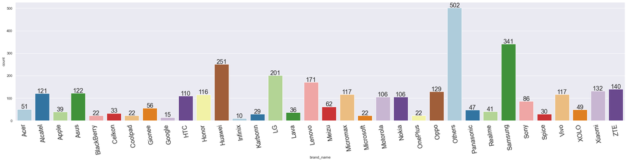

```python
# A Bar plot grouping the number of phones by brand
labeled_barplot(df, "brand_name")
```

##### The graph above shows that others, Samsung and Huawei are the most popular used phones in the market

## Exploratory Data Analysis (EDA)

- EDA is an important part of any project involving data.
- It is important to investigate and understand the data better before building a model with it.
- A few questions have been mentioned below which will help you approach the analysis in the right manner and generate insights from the data.
- A thorough analysis of the data, in addition to the questions mentioned below, should be done.

**Questions**:

1. What does the distribution of used device prices look like?
2. What percentage of the used device market is dominated by Android devices?
3. The amount of RAM is important for the smooth functioning of a device. How does the amount of RAM vary with the brand?
4. A large battery often increases a device's weight, making it feel uncomfortable in the hands. How does the weight vary for phones and tablets offering large batteries (more than 4500 mAh)?
5. Bigger screens are desirable for entertainment purposes as they offer a better viewing experience. How many phones and tablets are available across different brands with a screen size larger than 6 inches?
6. Budget devices nowadays offer great selfie cameras, allowing us to capture our favorite moments with loved ones. What is the distribution of budget devices offering greater than 8MP selfie cameras across brands?
7. Which attributes are highly correlated with the price of a used device?

## 1.What does the distribution of used device prices look like?

```python
# First we group the brand_name with their Mean prices
df.groupby("brand_name")["used_price"].mean().sort_values(ascending=False)
```

```
brand_name
OnePlus       183.223636
Apple         172.015385
Google        138.597333
Oppo          130.043566
Vivo          126.787094
Xiaomi        122.796288
Huawei        122.436813
Honor         114.489138
Meizu         108.286935
Realme        107.493171
Sony          101.721977
Samsung       101.570059
Asus           98.752295
Motorola       91.343962
HTC            88.801273
Gionee         88.591786
Lenovo         87.475380
ZTE            86.898286
Coolpad        84.915455
LG             84.610149
Infinix        81.126000
BlackBerry     80.341364
Microsoft      75.838636
Others         75.383606
Acer           73.611176
Panasonic      71.296809
Nokia          61.760943
Alcatel        60.090496
XOLO           53.538571
Lava           51.867500
Micromax       50.304957
Karbonn        49.286552
Spice          44.024333
Celkon         32.210909
Name: used_price, dtype: float64
```

##### Observations:

We can see that One plus, Apple and Google phones have the highest prices on Average

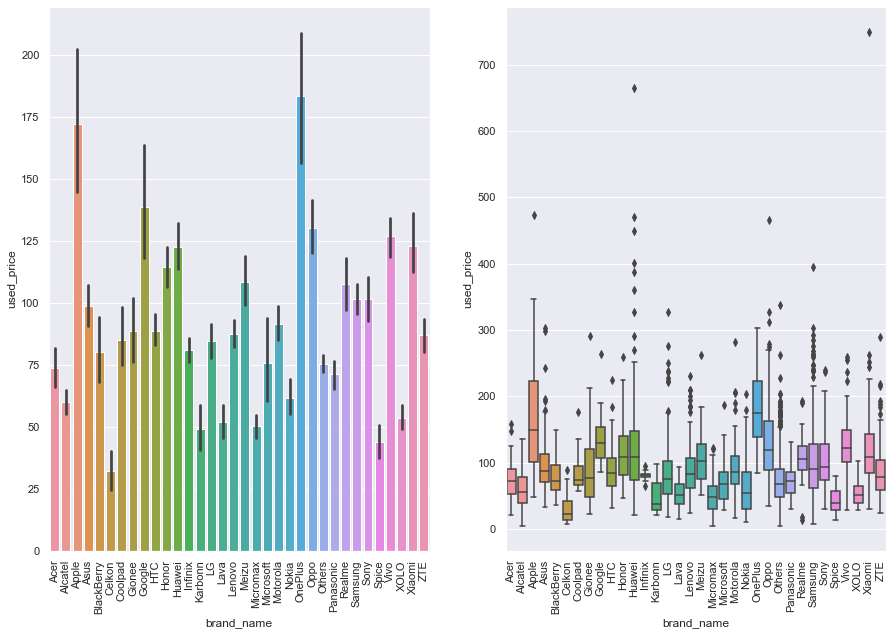

```python
# A Bar plot and a Box plot showing used_price across the brands, Xiomi and Huawei have the highest number of outliers
plt.figure(figsize=(15, 10))

plt.subplot(1, 2, 1)
sns.barplot(data=df, y="used_price", x="brand_name")
plt.xticks(rotation=90)

plt.subplot(1, 2, 2)
sns.boxplot(data=df, y="used_price", x="brand_name")
plt.xticks(rotation=90)

plt.show()
```

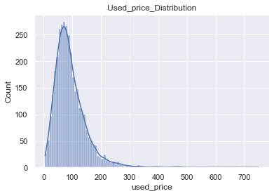

```python
# A histogram showing the distribution of used_price variable
sns.histplot(df["used_price"], kde=True)
plt.title("Used_price_Distribution")
plt.show()
```

## 2.What percentage of the used device market is dominated by Android devices?

```python
# Counting the number of phones by os
df1 = df[["os"]].value_counts()
print(df1)
```

```
os
Android    3214
Others      137
Windows      67
iOS          36
dtype: int64
```

```python
# Transposing the os type dataframe
d1 = {"Android": [3214], "Others": [137], "Windows": [67], "IOS": [36]}
df1 = pd.DataFrame(data=d1)
df1
```

|  | Android | Others | Windows | IOS |
| --- | --- | --- | --- | --- |
| 0 | 3214 | 137 | 67 | 36 |

```python
# Applying lambda function to find
# percentage of 'Android' column
# using df.assign()

# displaying the data frame
Total_phones = 3454
df1 = df1.assign(
    Percentage=lambda x: (x["Android"] / Total_phones * 100)
)  # Applying a lambda function to calculate the percentage
df1
```

|  | Android | Others | Windows | IOS | Percentage |
| --- | --- | --- | --- | --- | --- |
| 0 | 3214 | 137 | 67 | 36 | 93.051534 |

##### 2.Percentage of Android Phones is 93%

## 3.The amount of RAM is important for the smooth functioning of a device. How does the amount of RAM vary with the brand?

```python
# The amount of RAM in GB grouped by number of phones
df5 = df["ram"].value_counts()
print(df5)
```

```
4.00     2819
6.00      154
8.00      130
2.00       90
0.25       83
3.00       81
1.00       34
12.00      18
0.02       18
0.03       17
0.50        9
1.50        1
Name: ram, dtype: int64
```

```python
# The average amount of RAM by Make
df5 = df.groupby("brand_name")["ram"].mean().sort_values(ascending=False)
print(df5)
```

```
brand_name
OnePlus       6.363636
Oppo          4.961240
Vivo          4.756410
Huawei        4.655378
Honor         4.603448
Xiaomi        4.583333
Google        4.533333
Meizu         4.451613
Samsung       4.199413
Realme        4.195122
Sony          4.069767
Asus          4.049180
ZTE           4.023214
HTC           4.000000
Apple         4.000000
XOLO          4.000000
Microsoft     4.000000
Panasonic     4.000000
Coolpad       3.954545
Motorola      3.943396
LG            3.936567
Gionee        3.933036
Acer          3.901961
Lenovo        3.885965
BlackBerry    3.829545
Others        3.777888
Spice         3.750000
Micromax      3.679487
Alcatel       3.407025
Karbonn       3.353448
Lava          3.277778
Infinix       2.600000
Nokia         2.479906
Celkon        1.613636
Name: ram, dtype: float64
```

## 4.A large battery often increases a device's weight, making it feel uncomfortable in the hands. How does the weight vary for phones and tablets offering large batteries (more than 4500 mAh)?

```python
# All phone batteries with mAh over 4500 their corresponding weight
df6 = df[df["battery"] > 4500]
df6.sample(10)
```

|  | brand_name | os | screen_size | Four_G | Five_G | main_camera_mp | selfie_camera_mp | int_memory | ram | battery | weight | release_year | days_used | new_price | used_price |
| --- | --- | --- | --- | --- | --- | --- | --- | --- | --- | --- | --- | --- | --- | --- | --- |
| 60 | Infinix | Android | 15.39 | yes | no | 8.00 | 8.0 | 64.0 | 4.0 | 5000.0 | 185.0 | 2020 | 173 | 111.25 | 78.54 |
| 2275 | Others | Android | 25.43 | no | no | 2.00 | 2.0 | 16.0 | 4.0 | 6400.0 | 680.0 | 2013 | 832 | 229.96 | 141.70 |
| 673 | Others | Android | 17.40 | yes | no | 8.00 | 5.0 | 32.0 | 4.0 | 5000.0 | 214.0 | 2019 | 317 | 150.95 | 82.42 |
| 2564 | Samsung | Android | 25.43 | no | no | 3.15 | 1.3 | 16.0 | 4.0 | 6800.0 | 487.0 | 2014 | 564 | 299.16 | 114.77 |
| 1312 | Huawei | Android | 20.32 | yes | no | 5.00 | 2.0 | 32.0 | 4.0 | 4800.0 | 350.0 | 2017 | 690 | 159.44 | 92.92 |
| 3449 | Asus | Android | 15.34 | yes | no | 8.00 | 8.0 | 64.0 | 6.0 | 5000.0 | 190.0 | 2019 | 232 | 654.50 | 89.33 |
| 192 | Xiaomi | Android | 16.94 | yes | yes | 8.00 | 16.0 | 128.0 | 6.0 | 4800.0 | 208.0 | 2020 | 319 | 250.42 | 167.49 |
| 1916 | Micromax | Android | 20.32 | no | no | 5.00 | 2.0 | 16.0 | 4.0 | 4800.0 | 118.0 | 2013 | 1032 | 171.39 | 77.04 |
| 3409 | Realme | Android | 15.37 | yes | no | 8.00 | 13.0 | 64.0 | 4.0 | 5000.0 | 198.0 | 2019 | 293 | 143.65 | 88.92 |
| 1054 | Gionee | Android | 12.83 | yes | no | 13.00 | 5.0 | 32.0 | 4.0 | 6020.0 | 211.0 | 2015 | 892 | 330.02 | 149.14 |

```python
# All phone makes with their corresponding median weights
df6 = df.groupby("brand_name")["weight"].median()
print(df6)
```

```
brand_name
Acer          155.00
Alcatel       149.00
Apple         299.00
Asus          170.00
BlackBerry    167.50
Celkon        140.00
Coolpad       155.00
Gionee        151.50
Google        167.00
HTC           155.00
Honor         171.75
Huawei        175.00
Infinix       185.00
Karbonn       126.50
LG            152.00
Lava          137.00
Lenovo        165.40
Meizu         159.50
Micromax      143.00
Microsoft     146.00
Motorola      166.00
Nokia         145.00
OnePlus       180.00
Oppo          169.50
Others        154.50
Panasonic     146.70
Realme        195.00
Samsung       165.00
Sony          154.50
Spice         158.00
Vivo          167.80
XOLO          140.00
Xiaomi        180.00
ZTE           157.50
Name: weight, dtype: float64
```

```python
df6 = df[df["battery"] > 4500]
df6.sample(10)
```

|  | brand_name | os | screen_size | Four_G | Five_G | main_camera_mp | selfie_camera_mp | int_memory | ram | battery | weight | release_year | days_used | new_price | used_price |
| --- | --- | --- | --- | --- | --- | --- | --- | --- | --- | --- | --- | --- | --- | --- | --- |
| 1306 | Huawei | Android | 20.32 | yes | no | 8.0 | 8.0 | 16.0 | 4.0 | 4800.0 | 310.0 | 2017 | 773 | 270.06 | 128.24 |
| 423 | Acer | Android | 25.43 | no | no | 5.0 | 2.0 | 16.0 | 4.0 | 6100.0 | 147.5 | 2016 | 570 | 230.39 | 76.53 |
| 433 | Acer | Android | 25.43 | no | no | 5.0 | 2.0 | 16.0 | 4.0 | 5910.0 | 540.0 | 2015 | 899 | 249.10 | 101.92 |
| 299 | LG | Android | 15.44 | yes | yes | 5.0 | 10.0 | 128.0 | 8.0 | 5000.0 | 213.0 | 2020 | 248 | 699.31 | 102.92 |
| 2585 | Samsung | Android | 30.53 | no | no | 8.0 | 2.0 | 32.0 | 4.0 | 9500.0 | 732.0 | 2014 | 799 | 469.18 | 205.79 |
| 2996 | Xiaomi | Android | 18.01 | no | no | 8.0 | 5.0 | 16.0 | 4.0 | 6700.0 | 360.0 | 2014 | 615 | 241.13 | 86.76 |
| 3312 | Xiaomi | Android | 16.43 | yes | no | 12.0 | 32.0 | 128.0 | 6.0 | 5260.0 | 208.0 | 2019 | 391 | 280.49 | 185.83 |
| 3105 | ZTE | Android | 12.83 | yes | no | 13.0 | 13.0 | 32.0 | 4.0 | 5000.0 | 190.0 | 2016 | 793 | 229.03 | 103.57 |
| 2977 | Xiaomi | Android | 16.36 | yes | no | 16.0 | 5.0 | 16.0 | 4.0 | 4850.0 | 145.0 | 2016 | 799 | 150.51 | 65.52 |
| 389 | Apple | Others | 27.94 | yes | no | 12.0 | 7.0 | 128.0 | 6.0 | 5770.5 | 471.0 | 2020 | 248 | 800.09 | 296.26 |

## 5.Bigger screens are desirable for entertainment purposes as they offer a better viewing experience. How many phones and tablets are available across different brands with a screen size larger than 6 inches?

```python
# Filter the phones with screen_size over 6 inches
df9 = df[df["screen_size"] > 6.0]
df9.sample(10)
```

|  | brand_name | os | screen_size | Four_G | Five_G | main_camera_mp | selfie_camera_mp | int_memory | ram | battery | weight | release_year | days_used | new_price | used_price |
| --- | --- | --- | --- | --- | --- | --- | --- | --- | --- | --- | --- | --- | --- | --- | --- |
| 858 | Others | Android | 17.78 | no | no | 5.0 | 2.0 | 32.0 | 4.0 | 3000.0 | 299.00 | 2014 | 1090 | 131.16 | 79.29 |
| 2031 | Nokia | Android | 15.21 | yes | no | 5.0 | 20.0 | 128.0 | 4.0 | 3320.0 | 172.00 | 2019 | 294 | 619.70 | 180.00 |
| 1717 | LG | Android | 10.24 | no | no | 5.0 | 0.3 | 16.0 | 4.0 | 1700.0 | 140.45 | 2014 | 564 | 91.69 | 43.89 |
| 3379 | Motorola | Android | 15.32 | yes | no | 13.0 | 12.0 | 128.0 | 4.0 | 3500.0 | 176.00 | 2019 | 481 | 155.64 | 120.24 |
| 2385 | Samsung | Android | 12.85 | yes | no | 13.0 | 8.0 | 64.0 | 4.0 | 3000.0 | 154.00 | 2018 | 478 | 150.37 | 92.03 |
| 267 | Huawei | Android | 16.74 | yes | no | 13.0 | 16.0 | 128.0 | 4.0 | 4000.0 | 163.50 | 2019 | 181 | 189.13 | 133.54 |
| 547 | Alcatel | Android | 12.83 | no | no | 8.0 | 2.0 | 16.0 | 4.0 | 2500.0 | 189.00 | 2014 | 906 | 141.85 | 69.01 |
| 457 | Acer | Android | 15.24 | yes | no | 13.0 | 2.0 | 16.0 | 4.0 | 3300.0 | 229.00 | 2013 | 635 | 339.31 | 102.68 |
| 3258 | Oppo | Android | 15.37 | yes | no | 8.0 | 16.0 | 128.0 | 8.0 | 4000.0 | 189.00 | 2019 | 414 | 438.00 | 142.32 |
| 262 | Huawei | Android | 16.23 | yes | no | 13.0 | 8.0 | 64.0 | 4.0 | 4000.0 | 176.00 | 2019 | 253 | 150.84 | 81.70 |

```python
# Count number of phones with screen size over 6 inches 3362 phones
df9["screen_size"].count()
```

```
3362
```

```python
#Group the phones with their brand names. Others and Samsung have the highest number of phones with screen sizes over 6 inches.
df9.groupby("brand_name")["screen_size"].count().sort_values(ascending=False)
```

```
brand_name
Others        479
Samsung       334
Huawei        251
LG            197
Lenovo        171
ZTE           140
Xiaomi        132
Oppo          129
Asus          122
Vivo          117
Honor         116
Alcatel       115
HTC           110
Micromax      108
Motorola      106
Sony           86
Nokia          72
Meizu          62
Gionee         56
Acer           51
XOLO           49
Panasonic      47
Realme         41
Apple          39
Lava           36
Spice          30
Karbonn        29
Celkon         25
Microsoft      22
OnePlus        22
Coolpad        22
BlackBerry     21
Google         15
Infinix        10
Name: screen_size, dtype: int64
```

### 6. Budget devices nowadays offer great selfie cameras, allowing us to capture our favorite moments with loved ones. What is the distribution of budget devices offering greater than 8MP selfie cameras across brands?

```python
# Filter the data with corresponding screen sizes over 8MP
df8 = df[df["selfie_camera_mp"] > 8]
df8.sample(6)
```

|  | brand_name | os | screen_size | Four_G | Five_G | main_camera_mp | selfie_camera_mp | int_memory | ram | battery | weight | release_year | days_used | new_price | used_price |
| --- | --- | --- | --- | --- | --- | --- | --- | --- | --- | --- | --- | --- | --- | --- | --- |
| 365 | Samsung | Android | 15.37 | yes | yes | 8.0 | 32.0 | 128.0 | 6.0 | 4500.0 | 187.0 | 2020 | 248 | 429.21 | 168.39 |
| 2122 | Oppo | Android | 15.34 | yes | no | 8.0 | 16.0 | 256.0 | 4.0 | 3765.0 | 185.0 | 2019 | 366 | 400.52 | 209.93 |
| 2904 | Others | Android | 15.24 | yes | no | 16.0 | 16.0 | 64.0 | 4.0 | 3000.0 | 164.0 | 2018 | 486 | 300.76 | 133.07 |
| 263 | Huawei | Android | 16.59 | yes | yes | 13.0 | 16.0 | 512.0 | 12.0 | 4500.0 | 198.0 | 2019 | 488 | 1701.54 | 401.80 |
| 3395 | Oppo | Android | 15.37 | yes | yes | 8.0 | 32.0 | 128.0 | 8.0 | 4025.0 | 171.0 | 2019 | 225 | 586.50 | 274.22 |
| 273 | Huawei | Android | 15.34 | yes | no | 13.0 | 24.0 | 128.0 | 6.0 | 4000.0 | 178.0 | 2019 | 539 | 259.56 | 177.72 |

```python
# Count number of phones with selfie cameras with 8 inches and above
df8["selfie_camera_mp"].count()
```

```
655
```

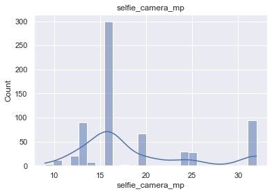

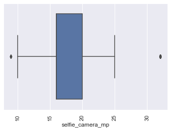

```python
# A histogram showing the distribution of selfie camera over 8MP
sns.histplot(df8["selfie_camera_mp"], kde=True)
plt.title("selfie_camera_mp")
plt.show()

sns.boxplot(data=df8, x="selfie_camera_mp")
plt.xticks(rotation=90)

plt.show()
```

### 7. Which attributes are highly correlated with the price of a used device?

```python
# Re-checking the variables dttaypes
df.info()
```

```
<class 'pandas.core.frame.DataFrame'>
RangeIndex: 3454 entries, 0 to 3453
Data columns (total 15 columns):
 #   Column            Non-Null Count  Dtype
---  ------            --------------  -----
 0   brand_name        3454 non-null   category
 1   os                3454 non-null   category
 2   screen_size       3454 non-null   float64
 3   Four_G            3454 non-null   category
 4   Five_G            3454 non-null   category
 5   main_camera_mp    3454 non-null   float64
 6   selfie_camera_mp  3454 non-null   float64
 7   int_memory        3454 non-null   float64
 8   ram               3454 non-null   float64
 9   battery           3454 non-null   float64
 10  weight            3454 non-null   float64
 11  release_year      3454 non-null   int64
 12  days_used         3454 non-null   int64
 13  new_price         3454 non-null   float64
 14  used_price        3454 non-null   float64
dtypes: category(4), float64(9), int64(2)
memory usage: 312.2 KB
```

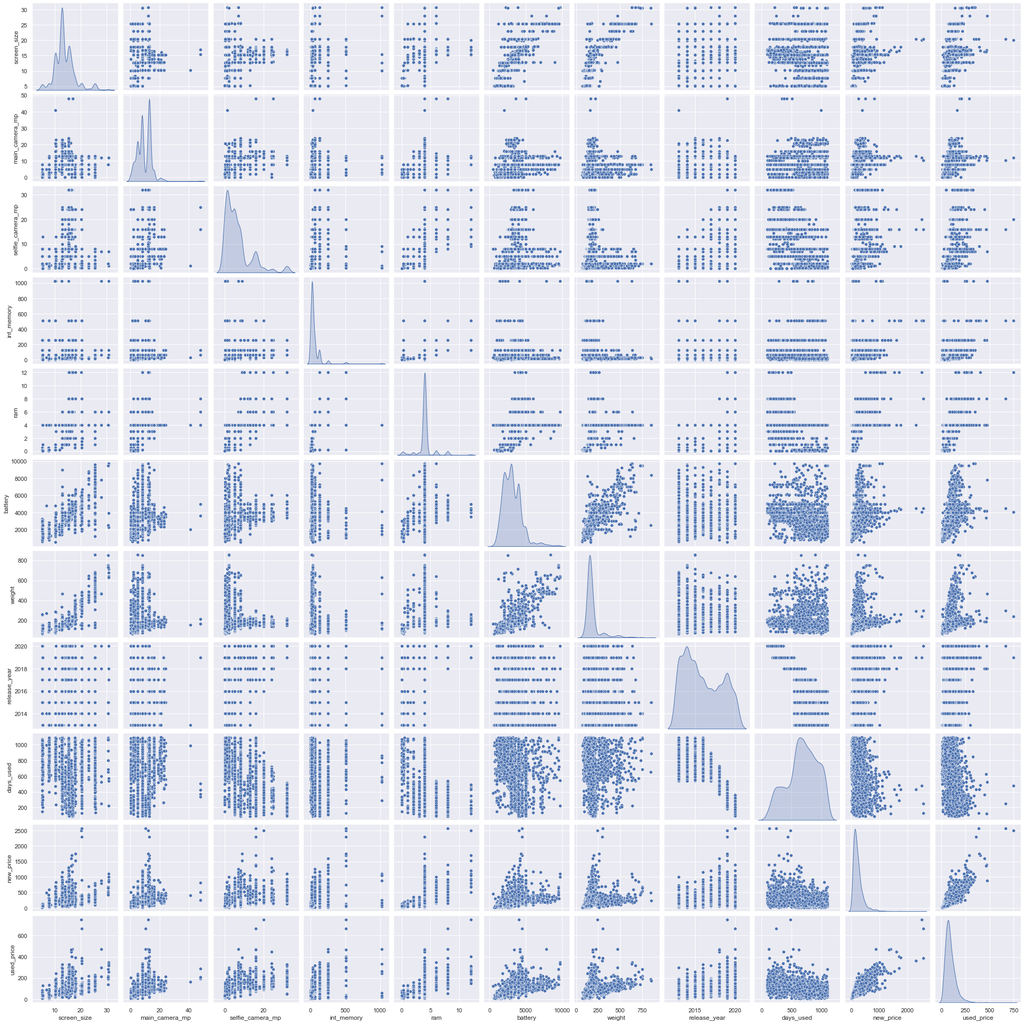

```python
# A pair plot to show which variables are highly collerated with used_price
sns.pairplot(
    df[
        [
            "brand_name",
            "os",
            "screen_size",
            "main_camera_mp",
            "selfie_camera_mp",
            "int_memory",
            "ram",
            "battery",
            "weight",
            "release_year",
            "days_used",
            "new_price",
            "used_price",
        ]
    ],
    diag_kind="kde",
)
# to plot density curve instead of histogram on the diag
```

##### Observations:

According to the pairplot above the New_price, Weight, Battery and the Main_camera_mp are the values that are highly collerated with the used_price.

## Data Preprocessing

- Missing value treatment
- Feature engineering (if needed)
- Outlier detection and treatment (if needed)
- Preparing data for modeling
- Any other preprocessing steps (if needed)

## EDA

- It is a good idea to explore the data once again after manipulating it.

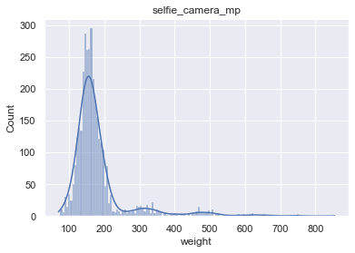

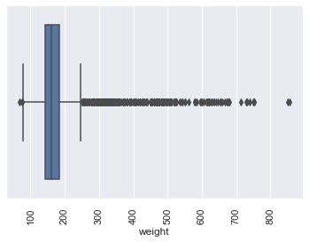

```python
# Check the weight column for outliers
sns.histplot(df["weight"], kde=True)
plt.title("selfie_camera_mp")
plt.show()

sns.boxplot(data=df, x="weight")
plt.xticks(rotation=90)

plt.show()
```

##### Observations:

The are very high number of outliers in the weight column and since weight is highly correlated with the used price the high number of outliers could affect our prediction.

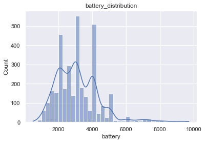

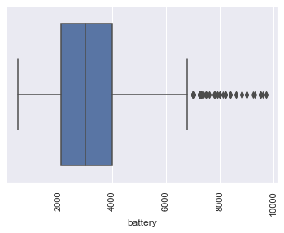

```python
# Check the battery column distribution and for outliers
sns.histplot(df["battery"], kde=True)
plt.title("battery_distribution")
plt.show()

sns.boxplot(data=df, x="battery")
plt.xticks(rotation=90)

plt.show()
```

#### Observations:

High number of outliers in the battery column

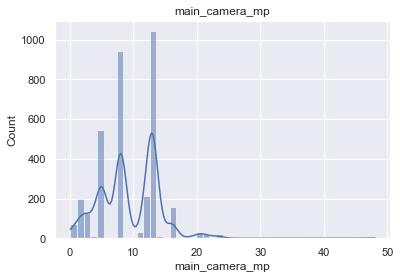

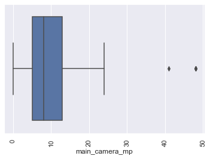

```python
# Check the main_camera_mp column distribution and for outliers
sns.histplot(df["main_camera_mp"], kde=True)
plt.title("main_camera_mp")
plt.show()

sns.boxplot(data=df, x="main_camera_mp")
plt.xticks(rotation=90)

plt.show()
```

##### Observations:

Shows few outliers

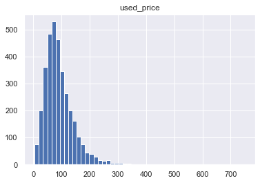

```
0
```

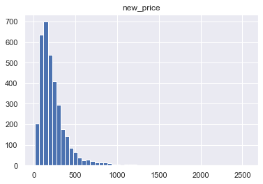

```
0
```

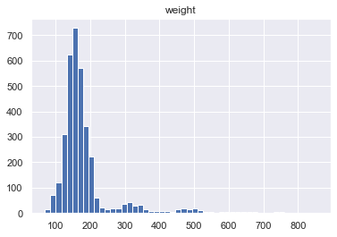

```
0
```

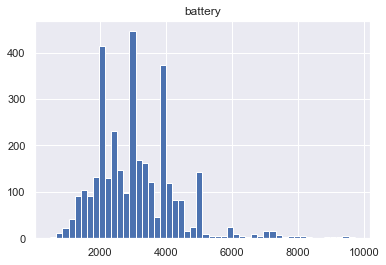

```
0
```

```python
# Transforming used_price", "new_price", "weight", "battery columns into log
cols_to_log = ["used_price", "new_price", "weight", "battery"]
for colname in cols_to_log:
    plt.hist(df[colname], bins=50)
    plt.title(colname)
    plt.show()
    print(np.sum(df[colname] <= 0))
```

Standardizing continuous features

```python
from sklearn.preprocessing import StandardScaler, MinMaxScaler
```

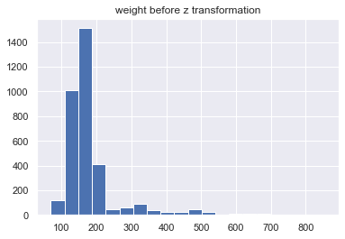

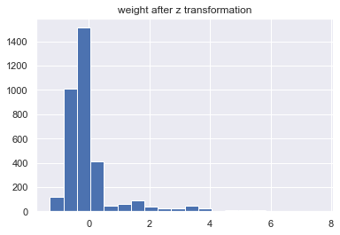

```python
std_scaler = StandardScaler()

df["weight"].hist(bins=20)
plt.title("weight before z transformation")
plt.show()
# fit_transform requires a DataFrame, not a Series, hence
# the double brackets to keep df[['Weight']] as a 1 column
# DataFrame rather than a Series, like if I did df['Weight']

df["weight_z_std"] = std_scaler.fit_transform(df[["weight"]])
df["weight_z_std"].hist(bins=20)
plt.title("weight after z transformation")
plt.show()
# exact same shape since it's a linear transformation.
df.drop(["weight"], axis=1, inplace=True)
```

## Building a Linear Regression model

```python
from sklearn.preprocessing import LabelEncoder
```

```python
# We are going to transform the brand_name variable into integers for our modelling
df["brand_name"] = pd.factorize(df.brand_name)[0]
df.sample(10)
```

|  | brand_name | os | screen_size | Four_G | Five_G | main_camera_mp | selfie_camera_mp | int_memory | ram | battery | release_year | days_used | new_price | used_price | weight_z_std |
| --- | --- | --- | --- | --- | --- | --- | --- | --- | --- | --- | --- | --- | --- | --- | --- |
| 2448 | 15 | Android | 12.83 | yes | no | 13.0 | 5.0 | 16.0 | 4.0 | 3300.0 | 2016 | 581 | 230.12 | 62.17 | -0.143866 |
| 1546 | 6 | Android | 10.16 | no | no | 5.0 | 0.3 | 32.0 | 4.0 | 2000.0 | 2015 | 1055 | 60.22 | 41.67 | -0.574136 |
| 506 | 23 | Android | 10.34 | yes | no | 13.0 | 5.0 | 32.0 | 4.0 | 2000.0 | 2015 | 736 | 201.62 | 97.28 | -0.823239 |
| 28 | 3 | Android | 15.37 | yes | yes | 10.5 | 16.0 | 64.0 | 6.0 | 4000.0 | 2020 | 299 | 220.53 | 124.02 | -0.007991 |
| 1652 | 7 | Android | 12.75 | yes | no | 16.0 | 5.0 | 32.0 | 4.0 | 4100.0 | 2017 | 616 | 280.74 | 85.01 | -0.183496 |
| 2922 | 17 | Android | 15.16 | yes | no | 12.0 | 20.0 | 64.0 | 4.0 | 3070.0 | 2019 | 353 | 303.24 | 154.57 | -0.313709 |
| 2471 | 15 | Android | 12.88 | yes | no | 16.0 | 5.0 | 32.0 | 4.0 | 3000.0 | 2015 | 835 | 598.83 | 211.32 | -0.132543 |
| 1874 | 9 | Android | 10.16 | no | no | 0.3 | 0.3 | 16.0 | 4.0 | 1200.0 | 2015 | 734 | 60.96 | 28.26 | -0.676042 |
| 13 | 0 | Android | 15.32 | yes | no | 13.0 | 16.0 | 64.0 | 4.0 | 4000.0 | 2019 | 336 | 221.13 | 101.25 | -0.126882 |
| 1913 | 9 | Android | 12.70 | no | no | 5.0 | 0.3 | 16.0 | 4.0 | 3000.0 | 2013 | 769 | 90.56 | 36.31 | -0.732656 |

```python
# Check if the brand_name has been transformed into an integer
df.info()
```

```
<class 'pandas.core.frame.DataFrame'>
RangeIndex: 3454 entries, 0 to 3453
Data columns (total 15 columns):
 #   Column            Non-Null Count  Dtype
---  ------            --------------  -----
 0   brand_name        3454 non-null   int64
 1   os                3454 non-null   category
 2   screen_size       3454 non-null   float64
 3   Four_G            3454 non-null   category
 4   Five_G            3454 non-null   category
 5   main_camera_mp    3454 non-null   float64
 6   selfie_camera_mp  3454 non-null   float64
 7   int_memory        3454 non-null   float64
 8   ram               3454 non-null   float64
 9   battery           3454 non-null   float64
 10  release_year      3454 non-null   int64
 11  days_used         3454 non-null   int64
 12  new_price         3454 non-null   float64
 13  used_price        3454 non-null   float64
 14  weight_z_std      3454 non-null   float64
dtypes: category(3), float64(9), int64(3)
memory usage: 334.5 KB
```

```python
df.sample(10)
```

|  | brand_name | os | screen_size | Four_G | Five_G | main_camera_mp | selfie_camera_mp | int_memory | ram | battery | release_year | days_used | new_price | used_price | weight_z_std |
| --- | --- | --- | --- | --- | --- | --- | --- | --- | --- | --- | --- | --- | --- | --- | --- |
| 3216 | 3 | Android | 17.83 | yes | yes | 13.0 | 24.0 | 256.0 | 8.00 | 4200.0 | 2019 | 279 | 488.75 | 173.64 | 0.569476 |
| 3024 | 33 | Android | 12.70 | no | no | 8.0 | 2.0 | 16.0 | 4.00 | 2250.0 | 2014 | 575 | 139.80 | 38.62 | -0.710010 |
| 644 | 19 | iOS | 30.71 | yes | no | 12.0 | 7.0 | 1024.0 | 4.00 | 9720.0 | 2018 | 543 | 1100.86 | 332.96 | 5.075985 |
| 1531 | 6 | Android | 20.32 | yes | no | 5.0 | 2.0 | 16.0 | 4.00 | 4290.0 | 2016 | 800 | 119.42 | 84.08 | 1.656473 |
| 2052 | 11 | Others | 5.18 | no | no | 2.0 | 0.0 | 0.1 | 0.02 | 1200.0 | 2017 | 680 | 70.58 | 36.69 | -1.070078 |
| 171 | 16 | Android | 17.50 | yes | yes | 13.0 | 16.0 | 256.0 | 8.00 | 4500.0 | 2019 | 288 | 731.33 | 139.87 | 0.405294 |
| 2441 | 15 | Others | 12.70 | yes | no | 8.0 | 5.0 | 32.0 | 4.00 | 2600.0 | 2016 | 907 | 201.00 | 78.33 | -0.291063 |
| 375 | 15 | Android | 12.70 | yes | no | 16.0 | 5.0 | 32.0 | 3.00 | 2800.0 | 2019 | 222 | 259.07 | 86.02 | -0.121220 |
| 2290 | 1 | Android | 10.16 | no | no | 2.0 | 0.3 | 16.0 | 4.00 | 2500.0 | 2015 | 737 | 59.08 | 33.28 | -0.325032 |
| 2700 | 31 | Android | 12.75 | yes | no | 23.0 | 5.1 | 32.0 | 4.00 | 2900.0 | 2015 | 694 | 250.52 | 110.35 | -0.325032 |

```python
# Converting os variable into dummy variables
df10 = pd.get_dummies(df.os)
df10
```

|  | Android | Others | Windows | iOS |
| --- | --- | --- | --- | --- |
| 0 | 1 | 0 | 0 | 0 |
| 1 | 1 | 0 | 0 | 0 |
| 2 | 1 | 0 | 0 | 0 |
| 3 | 1 | 0 | 0 | 0 |
| 4 | 1 | 0 | 0 | 0 |
| ... | ... | ... | ... | ... |
| 3449 | 1 | 0 | 0 | 0 |
| 3450 | 1 | 0 | 0 | 0 |
| 3451 | 1 | 0 | 0 | 0 |
| 3452 | 1 | 0 | 0 | 0 |
| 3453 | 1 | 0 | 0 | 0 |

3454 rows × 4 columns

```python
# Merging both dataframes
df11 = pd.concat([df, df10], axis="columns")
df11
```

|  | brand_name | os | screen_size | Four_G | Five_G | main_camera_mp | selfie_camera_mp | int_memory | ram | battery | release_year | days_used | new_price | used_price | weight_z_std | Android | Others | Windows | iOS |
| --- | --- | --- | --- | --- | --- | --- | --- | --- | --- | --- | --- | --- | --- | --- | --- | --- | --- | --- | --- |
| 0 | 0 | Android | 14.50 | yes | no | 13.0 | 5.0 | 64.0 | 3.0 | 3020.0 | 2020 | 127 | 111.62 | 74.26 | -0.415615 | 1 | 0 | 0 | 0 |
| 1 | 0 | Android | 17.30 | yes | yes | 13.0 | 16.0 | 128.0 | 8.0 | 4300.0 | 2020 | 325 | 249.39 | 174.53 | 0.343018 | 1 | 0 | 0 | 0 |
| 2 | 0 | Android | 16.69 | yes | yes | 13.0 | 8.0 | 128.0 | 8.0 | 4200.0 | 2020 | 162 | 359.47 | 165.85 | 0.343018 | 1 | 0 | 0 | 0 |
| 3 | 0 | Android | 25.50 | yes | yes | 13.0 | 8.0 | 64.0 | 6.0 | 7250.0 | 2020 | 345 | 278.93 | 169.93 | 3.366229 | 1 | 0 | 0 | 0 |
| 4 | 0 | Android | 15.32 | yes | no | 13.0 | 8.0 | 64.0 | 3.0 | 5000.0 | 2020 | 293 | 140.87 | 80.64 | 0.025977 | 1 | 0 | 0 | 0 |
| ... | ... | ... | ... | ... | ... | ... | ... | ... | ... | ... | ... | ... | ... | ... | ... | ... | ... | ... | ... |
| 3449 | 20 | Android | 15.34 | yes | no | 8.0 | 8.0 | 64.0 | 6.0 | 5000.0 | 2019 | 232 | 654.50 | 89.33 | 0.082592 | 1 | 0 | 0 | 0 |
| 3450 | 20 | Android | 15.24 | yes | no | 13.0 | 8.0 | 128.0 | 8.0 | 4000.0 | 2018 | 541 | 518.81 | 154.12 | 0.195821 | 1 | 0 | 0 | 0 |
| 3451 | 23 | Android | 15.80 | yes | no | 13.0 | 5.0 | 32.0 | 3.0 | 4000.0 | 2020 | 201 | 92.65 | 78.05 | -0.200480 | 1 | 0 | 0 | 0 |
| 3452 | 23 | Android | 15.80 | yes | no | 13.0 | 5.0 | 32.0 | 2.0 | 4000.0 | 2020 | 149 | 101.92 | 77.46 | -0.257095 | 1 | 0 | 0 | 0 |
| 3453 | 23 | Android | 12.83 | yes | no | 13.0 | 5.0 | 16.0 | 2.0 | 4000.0 | 2020 | 176 | 72.24 | 62.31 | -0.166512 | 1 | 0 | 0 | 0 |

3454 rows × 19 columns

```python
# Drop os and Others variables
df12 = df11.drop(["os", "Others"], axis="columns", inplace=True)
df12
```

```python
# check data_types
df11
```

|  | brand_name | screen_size | Four_G | Five_G | main_camera_mp | selfie_camera_mp | int_memory | ram | battery | release_year | days_used | new_price | used_price | weight_z_std | Android | Windows | iOS |
| --- | --- | --- | --- | --- | --- | --- | --- | --- | --- | --- | --- | --- | --- | --- | --- | --- | --- |
| 0 | 0 | 14.50 | yes | no | 13.0 | 5.0 | 64.0 | 3.0 | 3020.0 | 2020 | 127 | 111.62 | 74.26 | -0.415615 | 1 | 0 | 0 |
| 1 | 0 | 17.30 | yes | yes | 13.0 | 16.0 | 128.0 | 8.0 | 4300.0 | 2020 | 325 | 249.39 | 174.53 | 0.343018 | 1 | 0 | 0 |
| 2 | 0 | 16.69 | yes | yes | 13.0 | 8.0 | 128.0 | 8.0 | 4200.0 | 2020 | 162 | 359.47 | 165.85 | 0.343018 | 1 | 0 | 0 |
| 3 | 0 | 25.50 | yes | yes | 13.0 | 8.0 | 64.0 | 6.0 | 7250.0 | 2020 | 345 | 278.93 | 169.93 | 3.366229 | 1 | 0 | 0 |
| 4 | 0 | 15.32 | yes | no | 13.0 | 8.0 | 64.0 | 3.0 | 5000.0 | 2020 | 293 | 140.87 | 80.64 | 0.025977 | 1 | 0 | 0 |
| ... | ... | ... | ... | ... | ... | ... | ... | ... | ... | ... | ... | ... | ... | ... | ... | ... | ... |
| 3449 | 20 | 15.34 | yes | no | 8.0 | 8.0 | 64.0 | 6.0 | 5000.0 | 2019 | 232 | 654.50 | 89.33 | 0.082592 | 1 | 0 | 0 |
| 3450 | 20 | 15.24 | yes | no | 13.0 | 8.0 | 128.0 | 8.0 | 4000.0 | 2018 | 541 | 518.81 | 154.12 | 0.195821 | 1 | 0 | 0 |
| 3451 | 23 | 15.80 | yes | no | 13.0 | 5.0 | 32.0 | 3.0 | 4000.0 | 2020 | 201 | 92.65 | 78.05 | -0.200480 | 1 | 0 | 0 |
| 3452 | 23 | 15.80 | yes | no | 13.0 | 5.0 | 32.0 | 2.0 | 4000.0 | 2020 | 149 | 101.92 | 77.46 | -0.257095 | 1 | 0 | 0 |
| 3453 | 23 | 12.83 | yes | no | 13.0 | 5.0 | 16.0 | 2.0 | 4000.0 | 2020 | 176 | 72.24 | 62.31 | -0.166512 | 1 | 0 | 0 |

3454 rows × 17 columns

```python
# We are going to transform the Four_G variable into integers for our modelling
df13 = df11["Four_G"] = pd.factorize(df.Four_G)[0]
df13
```

```
array([0, 0, 0, ..., 0, 0, 0], dtype=int64)
```

```python
# Four_G variable converted into a series of zeros and ones
df["Four_G"].unique()
```

```
['yes', 'no']
Categories (2, object): ['yes', 'no']
```

```python
# We are going to transform the Five_G variable into integers for our modelling
df14 = df11["Five_G"] = pd.factorize(df.Five_G)[0]
df14
```

```
array([0, 1, 1, ..., 0, 0, 0], dtype=int64)
```

```python
# Confirming that the values Yes and No have been converted into a bunch of 0 and 1's
df11
```

|  | brand_name | screen_size | Four_G | Five_G | main_camera_mp | selfie_camera_mp | int_memory | ram | battery | release_year | days_used | new_price | used_price | weight_z_std | Android | Windows | iOS |
| --- | --- | --- | --- | --- | --- | --- | --- | --- | --- | --- | --- | --- | --- | --- | --- | --- | --- |
| 0 | 0 | 14.50 | 0 | 0 | 13.0 | 5.0 | 64.0 | 3.0 | 3020.0 | 2020 | 127 | 111.62 | 74.26 | -0.415615 | 1 | 0 | 0 |
| 1 | 0 | 17.30 | 0 | 1 | 13.0 | 16.0 | 128.0 | 8.0 | 4300.0 | 2020 | 325 | 249.39 | 174.53 | 0.343018 | 1 | 0 | 0 |
| 2 | 0 | 16.69 | 0 | 1 | 13.0 | 8.0 | 128.0 | 8.0 | 4200.0 | 2020 | 162 | 359.47 | 165.85 | 0.343018 | 1 | 0 | 0 |
| 3 | 0 | 25.50 | 0 | 1 | 13.0 | 8.0 | 64.0 | 6.0 | 7250.0 | 2020 | 345 | 278.93 | 169.93 | 3.366229 | 1 | 0 | 0 |
| 4 | 0 | 15.32 | 0 | 0 | 13.0 | 8.0 | 64.0 | 3.0 | 5000.0 | 2020 | 293 | 140.87 | 80.64 | 0.025977 | 1 | 0 | 0 |
| ... | ... | ... | ... | ... | ... | ... | ... | ... | ... | ... | ... | ... | ... | ... | ... | ... | ... |
| 3449 | 20 | 15.34 | 0 | 0 | 8.0 | 8.0 | 64.0 | 6.0 | 5000.0 | 2019 | 232 | 654.50 | 89.33 | 0.082592 | 1 | 0 | 0 |
| 3450 | 20 | 15.24 | 0 | 0 | 13.0 | 8.0 | 128.0 | 8.0 | 4000.0 | 2018 | 541 | 518.81 | 154.12 | 0.195821 | 1 | 0 | 0 |
| 3451 | 23 | 15.80 | 0 | 0 | 13.0 | 5.0 | 32.0 | 3.0 | 4000.0 | 2020 | 201 | 92.65 | 78.05 | -0.200480 | 1 | 0 | 0 |
| 3452 | 23 | 15.80 | 0 | 0 | 13.0 | 5.0 | 32.0 | 2.0 | 4000.0 | 2020 | 149 | 101.92 | 77.46 | -0.257095 | 1 | 0 | 0 |
| 3453 | 23 | 12.83 | 0 | 0 | 13.0 | 5.0 | 16.0 | 2.0 | 4000.0 | 2020 | 176 | 72.24 | 62.31 | -0.166512 | 1 | 0 | 0 |

3454 rows × 17 columns

##### Split the Data

```python
# independent variables
X = df11.drop(["used_price"], axis=1)
# dependent variable
y = df11[["used_price"]]
```

```python
# let's add the intercept to data
X = sm.add_constant(X)
```

## We will now split X and y into train and test sets in a 70:30 ratio.

```python
X_train, X_test, y_train, y_test = train_test_split(
    X, y, test_size=0.30, random_state=1
)
```

```python
print(X_train.head())
```

```
      const  brand_name  screen_size  Four_G  Five_G  main_camera_mp  \
3026    1.0          33        10.29       1       0             8.0
1525    1.0           6        15.34       0       0            13.0
1128    1.0           0        12.70       1       0            13.0
3003    1.0          33        12.83       0       0             8.0
2907    1.0           1        12.88       0       0            13.0

      selfie_camera_mp  int_memory  ram  battery  release_year  days_used  \
3026               0.3        16.0  4.0   1800.0          2014        819
1525               5.0        32.0  4.0   4050.0          2016        585
1128               5.0        32.0  4.0   2550.0          2015        727
3003               5.0        16.0  4.0   3200.0          2015        800
2907              16.0        16.0  4.0   2900.0          2017        560

      new_price  weight_z_std  Android  Windows  iOS
3026     121.05     -0.710010        1        0    0
1525     229.20      0.478893        1        0    0
1128     170.36     -0.234449        1        0    0
3003     179.33     -0.257095        1        0    0
2907     150.84     -0.257095        1        0    0
```

```python
print(X_test.head())
```

[output not shown]

## Model performance evaluation

```python
olsmod = sm.OLS(y_train, X_train)
olsres = olsmod.fit()
```

```python
# let's print the regression summary
print(olsres.summary())
```

[output not shown]

## Interpretation of R-squared

.The R-squared value tells us that our model can explain 82.5% of the variance in the training set.

## Checking Linear Regression Assumptions

- In order to make statistical inferences from a linear regression model, it is important to ensure that the assumptions of linear regression are satisfied.

Interpretation of Coefficients The coefficients tell us how one unit change in X can affect y.

The sign of the coefficient indicates if the relationship is positive or negative.

In this dataset, for example, an increase in 1GB of RAM occurs with a 2.9037 increase in used_price,

A phone's choice of os for example Android can see a decrease of $11 to the price of a used phone.

Earlier we saw that the relationship of used_price with new_price, weight, Battery and Main_camera_mp is almost the same (they have a positive correlation with used_price but in this case we have other candidates like screen_size, main_camera_mp, int_memory, ram and type of OS

Therefore, the signs of the coefficents should be the same. But we observe that it is not so. This indicates the presence of multicollinearity in our data.

Multicollinearity occurs when predictor variables in a regression model are correlated. This correlation is a problem because predictor variables should be independent. If the collinearity between variables is high, we might not be able to trust the p-values to identify independent variables that are statistically significant.

When we have multicollinearity in the linear model, the coefficients that the model suggests are unreliable.

## Interpretation of p-values (P > |t|)

at 0.05 significance level

For each predictor variable there is a null hypothesis and alternate hypothesis.

- Null hypothesis : Predictor variable is not significant
- Alternate hypothesis : Predictor variable is significant

```python
# let's check the VIF of the predictors
from statsmodels.stats.outliers_influence import variance_inflation_factor

vif_series1 = pd.Series(
    [variance_inflation_factor(X_train.values, i) for i in range(X_train.shape[1])],
    index=X_train.columns,
)
print("VIF values: \n\n{}\n".format(vif_series1))
```

```
VIF values:

const               3.380175e+06
brand_name          1.034045e+00
screen_size         7.199913e+00
Four_G              2.172307e+00
Five_G              1.780845e+00
main_camera_mp      1.784206e+00
selfie_camera_mp    2.496679e+00
int_memory          1.397899e+00
ram                 2.106699e+00
battery             3.816535e+00
weight              6.178040e+00
release_year        4.369141e+00
days_used           2.588590e+00
new_price           2.018993e+00
Android             2.514565e+00
Windows             1.623036e+00
iOS                 1.531503e+00
dtype: float64
```

```python
#evaluate the P-Values
olsmod_9 = sm.OLS(y_train, X_train)
olsres_9 = olsmod_9.fit()
print(olsres_9.summary())
```

```
                            OLS Regression Results
==============================================================================
Dep. Variable:             used_price   R-squared:                       0.825
Model:                            OLS   Adj. R-squared:                  0.824
Method:                 Least Squares   F-statistic:                     705.9
Date:                Wed, 02 Mar 2022   Prob (F-statistic):               0.00
Time:                        11:35:42   Log-Likelihood:                -11031.
No. Observations:                2417   AIC:                         2.210e+04
Df Residuals:                    2400   BIC:                         2.219e+04
Df Model:                          16
Covariance Type:            nonrobust
====================================================================================
                       coef    std err          t      P>|t|      [0.025      0.975]
------------------------------------------------------------------------------------
const            -2024.2128    871.459     -2.323      0.020   -3733.102    -315.324
brand_name           0.0490      0.053      0.930      0.353      -0.054       0.152
screen_size          1.5381      0.331      4.646      0.000       0.889       2.187
Four_G              -1.2829      1.493     -0.859      0.390      -4.211       1.645
Five_G               3.4202      3.132      1.092      0.275      -2.721       9.561
main_camera_mp       1.6757      0.135     12.430      0.000       1.411       1.940
selfie_camera_mp     1.8029      0.106     16.958      0.000       1.594       2.011
int_memory           0.0673      0.007      9.498      0.000       0.053       0.081
ram                  2.9037      0.498      5.829      0.000       1.927       3.881
battery             -0.0006      0.001     -0.786      0.432      -0.002       0.001
weight               0.1101      0.013      8.366      0.000       0.084       0.136
release_year         0.9971      0.432      2.309      0.021       0.150       1.844
days_used            0.0017      0.003      0.546      0.585      -0.004       0.008
new_price            0.1425      0.003     42.303      0.000       0.136       0.149
Android            -11.6455      2.939     -3.962      0.000     -17.410      -5.881
Windows             -8.6255      4.568     -1.888      0.059     -17.583       0.333
iOS                 -8.6686      5.298     -1.636      0.102     -19.058       1.721
==============================================================================
Omnibus:                      449.426   Durbin-Watson:                   1.925
Prob(Omnibus):                  0.000   Jarque-Bera (JB):            10280.864
Skew:                           0.195   Prob(JB):                         0.00
Kurtosis:                      13.096   Cond. No.                     7.28e+06
==============================================================================

Notes:
[1] Standard Errors assume that the covariance matrix of the errors is correctly specified.
[2] The condition number is large, 7.28e+06. This might indicate that there are
strong multicollinearity or other numerical problems.
```

## Remove the non-significant predictor variables.

```python
X_train8 = X_train.drop(["brand_name",'Four_G','Five_G','battery','days_used','Windows','iOS'], axis=1)
olsmod_13 = sm.OLS(y_train, X_train8)
olsres_13 = olsmod_13.fit()
print(olsres_13.summary())
```

```
                            OLS Regression Results
==============================================================================
Dep. Variable:             used_price   R-squared:                       0.824
Model:                            OLS   Adj. R-squared:                  0.823
Method:                 Least Squares   F-statistic:                     1253.
Date:                Wed, 02 Mar 2022   Prob (F-statistic):               0.00
Time:                        11:50:13   Log-Likelihood:                -11035.
No. Observations:                2417   AIC:                         2.209e+04
Df Residuals:                    2407   BIC:                         2.215e+04
Df Model:                           9
Covariance Type:            nonrobust
====================================================================================
                       coef    std err          t      P>|t|      [0.025      0.975]
------------------------------------------------------------------------------------
const            -2113.2872    618.423     -3.417      0.001   -3325.983    -900.592
screen_size          1.2900      0.307      4.209      0.000       0.689       1.891
main_camera_mp       1.6572      0.121     13.707      0.000       1.420       1.894
selfie_camera_mp     1.8147      0.105     17.210      0.000       1.608       2.021
int_memory           0.0676      0.007      9.660      0.000       0.054       0.081
ram                  2.9607      0.439      6.748      0.000       2.100       3.821
weight               0.1110      0.012      9.104      0.000       0.087       0.135
release_year         1.0405      0.307      3.387      0.001       0.438       1.643
new_price            0.1431      0.003     44.186      0.000       0.137       0.149
Android             -7.3777      2.089     -3.531      0.000     -11.475      -3.281
==============================================================================
Omnibus:                      452.520   Durbin-Watson:                   1.929
Prob(Omnibus):                  0.000   Jarque-Bera (JB):            10348.224
Skew:                           0.209   Prob(JB):                         0.00
Kurtosis:                      13.128   Cond. No.                     2.66e+06
==============================================================================

Notes:
[1] Standard Errors assume that the covariance matrix of the errors is correctly specified.
[2] The condition number is large, 2.66e+06. This might indicate that there are
strong multicollinearity or other numerical problems.
```

##### .The R Squared and and the adjusted R Squared drops slightly to 82.4% and 82.3% respectively

```python
df_pred = pd.DataFrame()

df_pred["Actual Values"] = y_train.values.flatten()  # actual values
df_pred["Fitted Values"] = olsres_13.fittedvalues.values  # predicted values
df_pred["Residuals"] = olsres_13.resid.values  # residuals

df_pred.head()
```

|  | Actual Values | Fitted Values | Residuals |
| --- | --- | --- | --- |
| 0 | 59.59 | 45.493834 | 14.096166 |
| 1 | 85.49 | 99.115575 | -13.625575 |
| 2 | 74.84 | 79.256918 | -4.416918 |
| 3 | 72.39 | 71.118510 | 1.271490 |
| 4 | 86.18 | 97.435852 | -11.255852 |

##### TEST FOR LINEARITY AND INDEPENDENCE

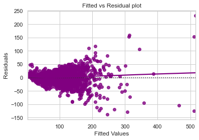

```python
# let us plot the fitted values vs residuals
sns.set_style("whitegrid")
sns.residplot(
    data=df_pred, x="Fitted Values", y="Residuals", color="purple", lowess=True
)
plt.xlabel("Fitted Values")
plt.ylabel("Residuals")
plt.title("Fitted vs Residual plot")
plt.show()
```

```python
# columns in training set
X_train8.columns
```

```
Index(['const', 'screen_size', 'main_camera_mp', 'selfie_camera_mp',
       'int_memory', 'ram', 'weight', 'release_year', 'new_price', 'Android'],
      dtype='object')
```

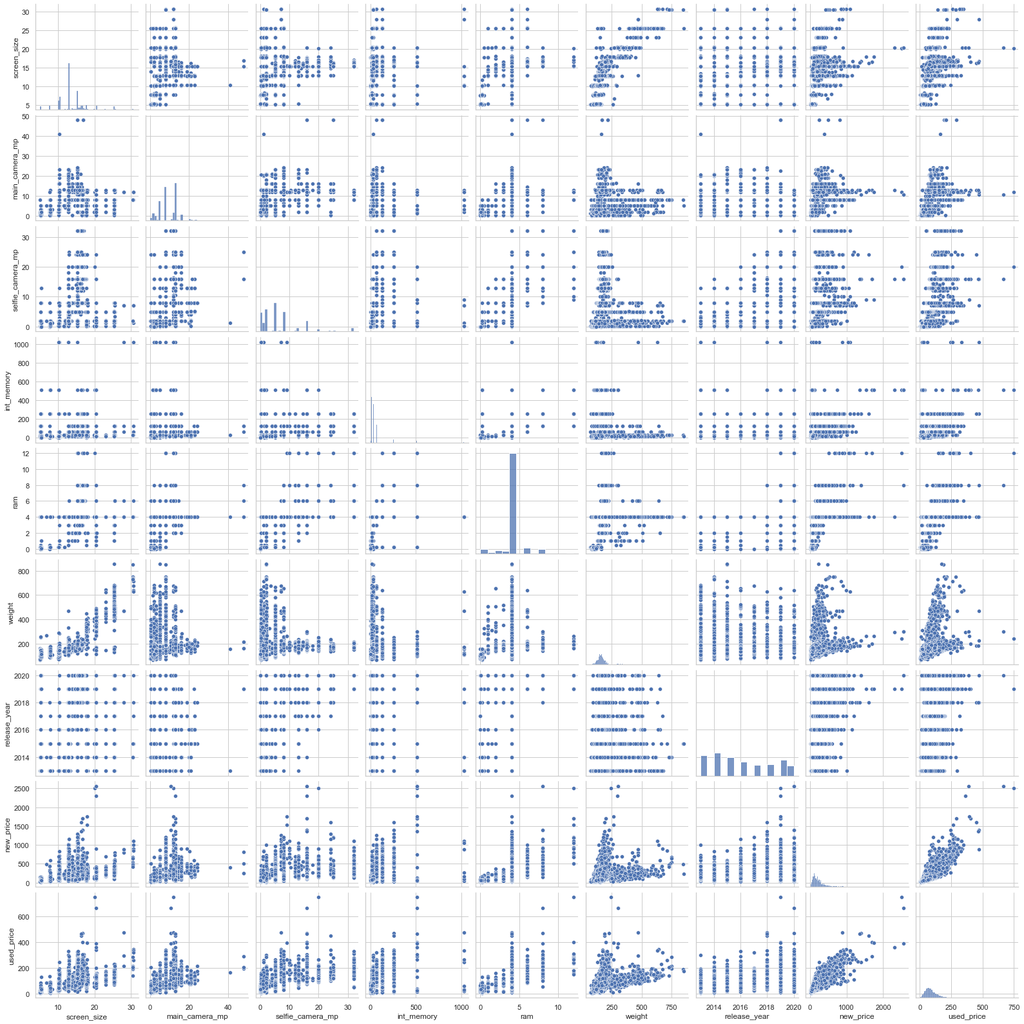

```python
# checking the distribution of variables in training set with dependent variable
sns.pairplot(
    df[
        [
            "screen_size",
            "main_camera_mp",
            "selfie_camera_mp",
            "int_memory",
            "ram",
            "weight",
            "release_year",
            "new_price",
            "os",
            "used_price",
        ]
    ]
)
plt.show()
```

```python
# using square transformation
X_train8["weight_sq"] = np.square(X_train8["weight"])

# let's create a model with the transformed data
olsmod_15 = sm.OLS(y_train, X_train8)
olsres_15 = olsmod_15.fit()
print(olsres_15.summary())
```

```
                            OLS Regression Results
==============================================================================
Dep. Variable:             used_price   R-squared:                       0.824
Model:                            OLS   Adj. R-squared:                  0.824
Method:                 Least Squares   F-statistic:                     1128.
Date:                Wed, 02 Mar 2022   Prob (F-statistic):               0.00
Time:                        12:35:59   Log-Likelihood:                -11035.
No. Observations:                2417   AIC:                         2.209e+04
Df Residuals:                    2406   BIC:                         2.215e+04
Df Model:                          10
Covariance Type:            nonrobust
====================================================================================
                       coef    std err          t      P>|t|      [0.025      0.975]
------------------------------------------------------------------------------------
const            -2193.8639    621.881     -3.528      0.000   -3413.343    -974.385
screen_size          1.3706      0.314      4.371      0.000       0.756       1.985
main_camera_mp       1.6481      0.121     13.606      0.000       1.411       1.886
selfie_camera_mp     1.8128      0.105     17.192      0.000       1.606       2.020
int_memory           0.0675      0.007      9.654      0.000       0.054       0.081
ram                  2.9842      0.439      6.795      0.000       2.123       3.845
weight               0.0803      0.028      2.866      0.004       0.025       0.135
release_year         1.0817      0.309      3.500      0.000       0.476       1.688
new_price            0.1433      0.003     44.195      0.000       0.137       0.150
Android             -7.1422      2.098     -3.404      0.001     -11.256      -3.028
weight_sq         4.317e-05   3.54e-05      1.219      0.223   -2.63e-05       0.000
==============================================================================
Omnibus:                      452.319   Durbin-Watson:                   1.926
Prob(Omnibus):                  0.000   Jarque-Bera (JB):            10334.648
Skew:                           0.209   Prob(JB):                         0.00
Kurtosis:                      13.121   Cond. No.                     9.51e+07
==============================================================================

Notes:
[1] Standard Errors assume that the covariance matrix of the errors is correctly specified.
[2] The condition number is large, 9.51e+07. This might indicate that there are
strong multicollinearity or other numerical problems.
```

```python
# let us recreate the dataframe with actual, fitted and residual values
df_pred = pd.DataFrame()

df_pred["Actual Values"] = y_train.values.flatten()  # actual values
df_pred["Fitted Values"] = olsres_15.fittedvalues.values  # predicted values
df_pred["Residuals"] = olsres_15.resid.values  # residuals

df_pred.head()
```

|  | Actual Values | Fitted Values | Residuals |
| --- | --- | --- | --- |
| 0 | 59.59 | 45.936106 | 13.653894 |
| 1 | 85.49 | 98.348423 | -12.858423 |
| 2 | 74.84 | 79.108795 | -4.268795 |
| 3 | 72.39 | 71.062894 | 1.327106 |
| 4 | 86.18 | 97.394238 | -11.214238 |

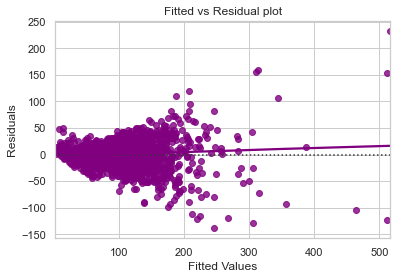

```python
# let us plot the fitted values vs residuals
sns.set_style("whitegrid")
sns.residplot(
    data=df_pred, x="Fitted Values", y="Residuals", color="purple", lowess=True
)
plt.xlabel("Fitted Values")
plt.ylabel("Residuals")
plt.title("Fitted vs Residual plot")
plt.show()
```

##### Observations: A slight or no change in how the residuals are spread

TEST FOR NORMALITY

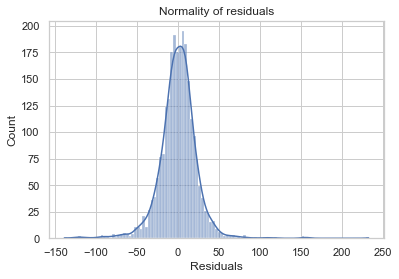

```python
sns.histplot(df_pred["Residuals"], kde=True)
plt.title("Normality of residuals")
plt.show()
```

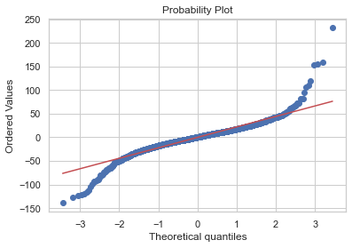

```python
import pylab
import scipy.stats as stats

stats.probplot(df_pred["Residuals"], dist="norm", plot=pylab)
plt.show()
```

The QQ plot most of the points are lying on the straight line

The Shapiro-Wilk test can also be used for checking the normality. The null and alternate hypotheses of the test are as follows:

Null hypothesis - Data is normally distributed. Alternate hypothesis - Data is not normally distributed.

```python
stats.shapiro(df_pred["Residuals"])
```

```
ShapiroResult(statistic=0.9081472754478455, pvalue=6.604423605077753e-36)
```

Since p-value < 0.05, the residuals are not normal as per shapiro test. We might be willing to accept this distribution as close to being normal

TEST FOR HOMOSCEDASTICITY

The null and alternate hypotheses of the goldfeldquandt test are as follows:

Null hypothesis : Residuals are homoscedastic Alternate hypothesis : Residuals have hetroscedasticity

```python
import statsmodels.stats.api as sms
from statsmodels.compat import lzip
```

```python
name = ["F statistic", "p-value"]
test = sms.het_goldfeldquandt(df_pred["Residuals"], X_train8)
lzip(name, test)
```

```
[('F statistic', 0.8390807256332089), ('p-value', 0.998789587036557)]
```

##### .Observations: Since p-value > 0.05 we can say that the residuals are homoscedastic.

```python
print(olsres_15.summary())
```

```
                            OLS Regression Results
==============================================================================
Dep. Variable:             used_price   R-squared:                       0.824
Model:                            OLS   Adj. R-squared:                  0.824
Method:                 Least Squares   F-statistic:                     1128.
Date:                Wed, 02 Mar 2022   Prob (F-statistic):               0.00
Time:                        12:43:59   Log-Likelihood:                -11035.
No. Observations:                2417   AIC:                         2.209e+04
Df Residuals:                    2406   BIC:                         2.215e+04
Df Model:                          10
Covariance Type:            nonrobust
====================================================================================
                       coef    std err          t      P>|t|      [0.025      0.975]
------------------------------------------------------------------------------------
const            -2193.8639    621.881     -3.528      0.000   -3413.343    -974.385
screen_size          1.3706      0.314      4.371      0.000       0.756       1.985
main_camera_mp       1.6481      0.121     13.606      0.000       1.411       1.886
selfie_camera_mp     1.8128      0.105     17.192      0.000       1.606       2.020
int_memory           0.0675      0.007      9.654      0.000       0.054       0.081
ram                  2.9842      0.439      6.795      0.000       2.123       3.845
weight               0.0803      0.028      2.866      0.004       0.025       0.135
release_year         1.0817      0.309      3.500      0.000       0.476       1.688
new_price            0.1433      0.003     44.195      0.000       0.137       0.150
Android             -7.1422      2.098     -3.404      0.001     -11.256      -3.028
weight_sq         4.317e-05   3.54e-05      1.219      0.223   -2.63e-05       0.000
==============================================================================
Omnibus:                      452.319   Durbin-Watson:                   1.926
Prob(Omnibus):                  0.000   Jarque-Bera (JB):            10334.648
Skew:                           0.209   Prob(JB):                         0.00
Kurtosis:                      13.121   Cond. No.                     9.51e+07
==============================================================================

Notes:
[1] Standard Errors assume that the covariance matrix of the errors is correctly specified.
[2] The condition number is large, 9.51e+07. This might indicate that there are
strong multicollinearity or other numerical problems.
```

Observations: R-squared of the model is 0.824 and adjusted R-squared is 0.824, which shows that the model is able to explain ~82% variance in the data. This is quite good.

The os type Android seems to have the biggest influence on used_price,

##### Predictions

Let's print the linear regression equation.

```python
# let's check the model parameters
olsres_15.params
```

```
const              -2193.863894
screen_size            1.370563
main_camera_mp         1.648106
selfie_camera_mp       1.812759
int_memory             0.067513
ram                    2.984188
weight                 0.080284
release_year           1.081676
new_price              0.143258
Android               -7.142213
weight_sq              0.000043
dtype: float64
```

```python
# Let us write the equation of linear regression
Equation = "used_price ="
print(Equation, end=" ")
for i in range(len(X_train8.columns)):
    if i == 0:
        print(olsres_15.params[i], "+", end=" ")
    elif i != len(X_train8.columns) - 1:
        print(
            olsres_15.params[i], "* (", X_train8.columns[i], ")", "+", end="  ",
        )
    else:
        print(olsres_15.params[i], "* (", X_train8.columns[i], ")")
```

[output not shown]

##### We can now use the model for making predictions on the test data.

```python
X_train8.columns
```

```
Index(['const', 'screen_size', 'main_camera_mp', 'selfie_camera_mp',
       'int_memory', 'ram', 'weight', 'release_year', 'new_price', 'Android',
       'weight_sq'],
      dtype='object')
```

```python
X_test.columns
```

```
Index(['const', 'brand_name', 'screen_size', 'Four_G', 'Five_G',
       'main_camera_mp', 'selfie_camera_mp', 'int_memory', 'ram', 'battery',
       'weight', 'release_year', 'days_used', 'new_price', 'Android',
       'Windows', 'iOS'],
      dtype='object')
```

Final Model Summary

```python
# dropping columns from the test data that are not there in the training data
X_test2 = X_test.drop(
    ["brand_name", "Four_G", "Five_G", "battery", "days_used", "Windows", "iOS"], axis=1
)
```

```python
# transforming the weight column in the test data corresponding to the training set
X_test2["weight_sq"] = np.square(X_test2["weight"])
```

```python
# let's make predictions on the test set
y_pred = olsres_15.predict(X_test2)
```

```python
# let's check the RMSE on the train data
rmse1 = np.sqrt(mean_squared_error(y_train, df_pred["Fitted Values"]))
rmse1
```

```
23.25326920413459
```

```python
# let's check the RMSE on the test data
rmse2 = np.sqrt(mean_squared_error(y_test, y_pred))
rmse2
```

```
22.666335894267313
```

```python
# let's check the MAE on the train data
mae1 = mean_absolute_error(y_train, df_pred["Fitted Values"])
mae1
```

```
16.000615685349796
```

```python
# let's check the MAE on the test data
mae2 = mean_absolute_error(y_test, y_pred)
mae2
```

```
15.799973201026377
```

## Actionable Insights and Recommendations

-

.Surprisingly factors like "brand_name", the network type, and 'days_used' don't seem to have a significant effect on the used_price.

.Android phones are the most popular and can have a significant effect on the price variation.

.Observations: R-squared of the model is 0.824 and adjusted R-squared is 0.824, which shows that the model is able to explain ~82% variance in the data.

.We can see that RMSE on the train and test sets are comparable. So, our model is not suffering from overfitting.

.MAE indicates that our current model is able to predict used_price within a mean error of 15 on the test data.

Hence, we can conclude the model "ols_res15" is good for prediction as well as inference purposes.

.The business should focus on screen_size, main_camera_mp, selfie_camera_mp, int_memory, ram, weight, release_year new_price, and os type Android, as the factors with the highest influence on price.